# Atividade Avaliativa 01

Aluno: Pedro Tashima

## Introdução

O sono está intimamente ligado ao bem-estar psicológico, segundo a Academia Brasileira do Sono (2024), o sono é fundamental para a regulação emocional, a capacidade cognitiva, a prevenção de transtornos mentais, resiliência psicológica, entre outros aspectos da saúde mental.

Este relatório utiliza dados de uma pesquisa realizada pelo setor de recursos humanos (RH) com uma amostra dos colaboradores de uma empresa. Seu objetivo é sugerir mudanças práticas e realistas de comportamento, principalmente ligadas ao sono, que promovam a saúde mental dos colaboradores. Para isso, como contexto, serão apresentadas análises dos dados coletados e, ao final, recomendações para o setor de RH.

### Distúrbios do sono

Dentre os 374 colaboradores analisados, 155 apresentavam algum tipo de distúrbio do sono, 41% do total, um percentual extremamente significativo (ver gráfico 1).

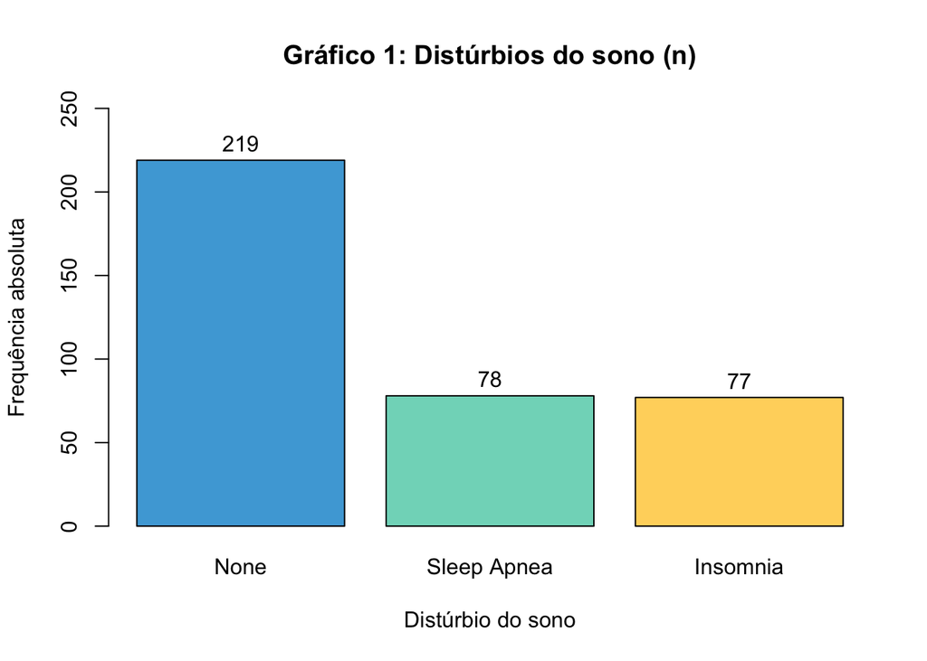

### Quantidade de sono

A mediana da quantidade de sono dos colaboradores é de 7.2 horas, com uma variância de 0.6330696 (gráfico 2), indicando que, apesar de uma mediana saudável (ACADEMIA BRASILEIRA DO SONO, 2025), muitos colaboradores estão no quartil inferior com uma quantidade insuficiente de horas de sono por noite (gráfico 3).

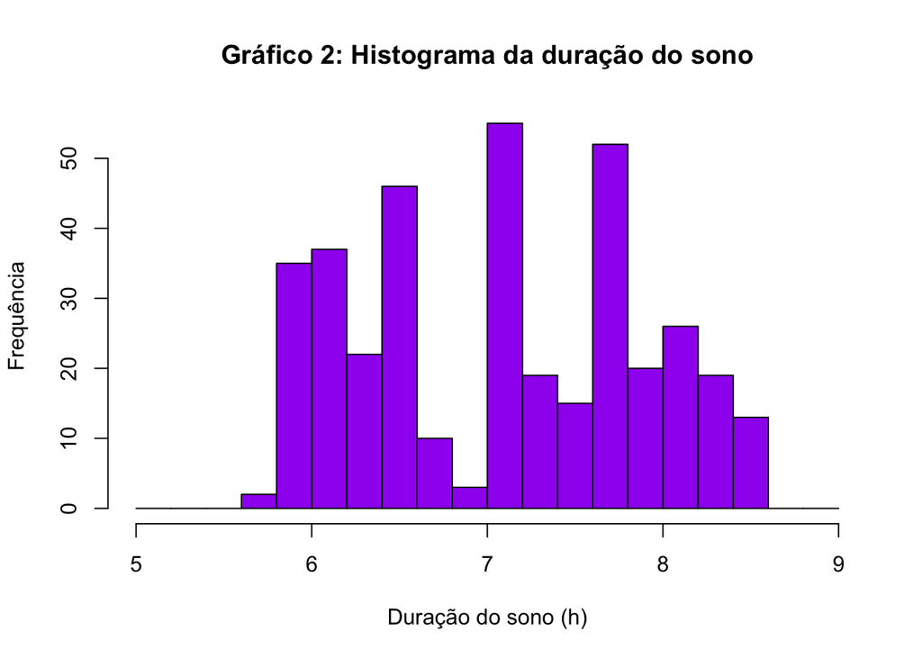

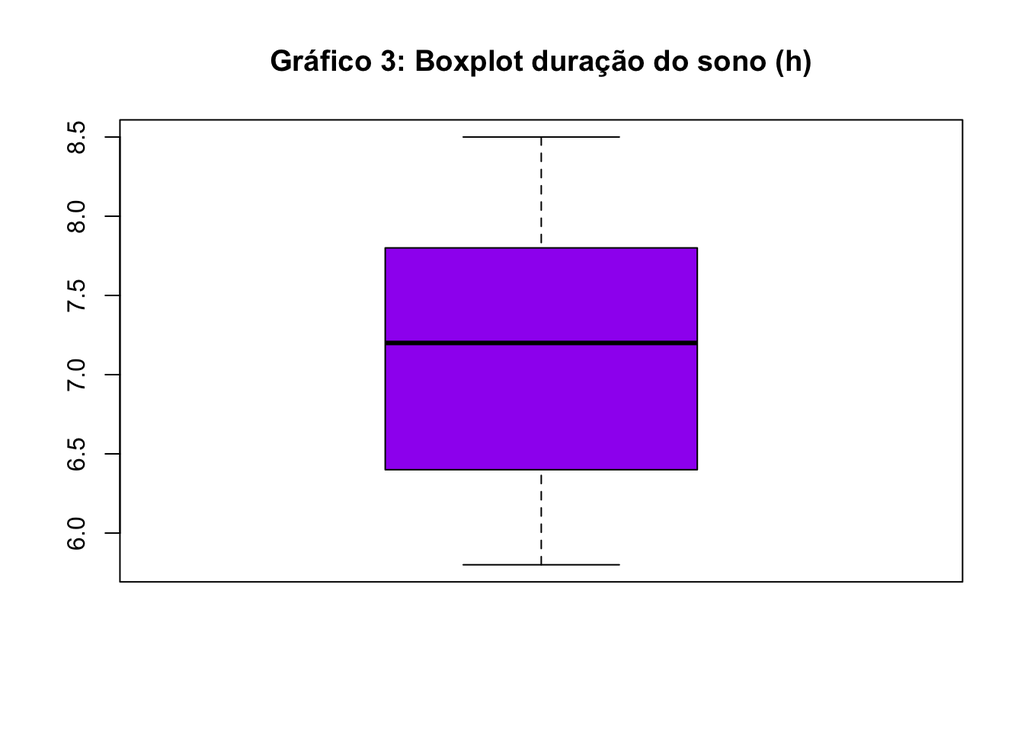

### Distúrbios do sono

Dentre os colaboradores analisados, observa-se que uma quantidade preocupante de mulheres que sofrem com apneia do sono (tabela 1).

**Tabela 1: Tabela de contingência percentual de distúrbios do sono por gênero**

```
##
##          Insomnia None Sleep Apnea
##   Female       19   44          36
##   Male         22   72           6
```

Colaboradores com distúrbios do sono têm uma mediana de horas de sono, muito menor do que colaboradores sem nenhum distúrbio. Quando distúrbios são comparados, colaboradores com insônia têm uma mediana de sono menor que os com apneia do sono, porém os dois cenários são preocupantes, pois o quartil inferior dos dois distúrbios está em um nível muito baixo (gráfico 4).

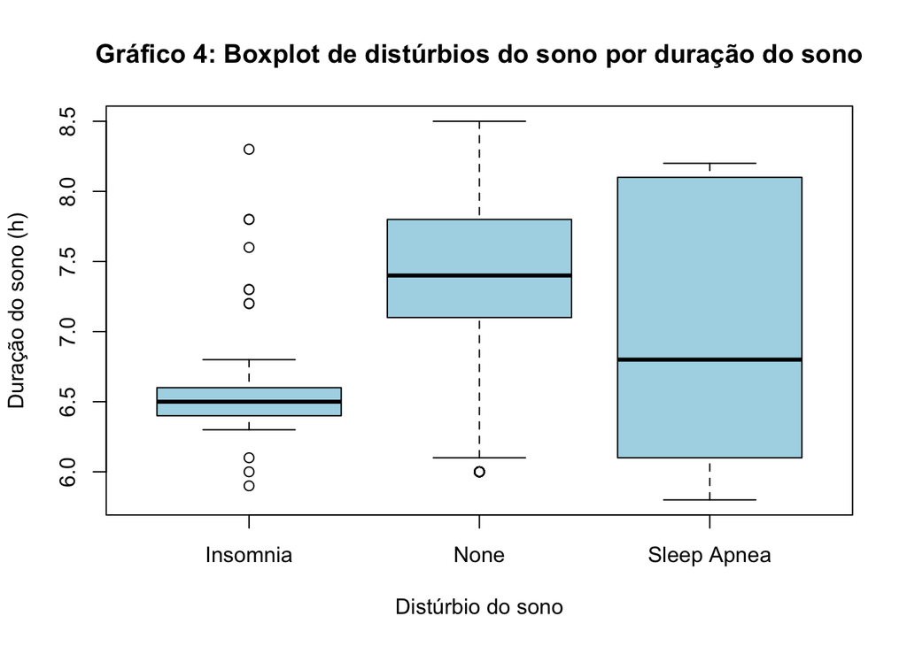

## Recomendações

Com base nas análises realizadas, recomenda-se ao setor de recursos humanos realizar ações, principalmente de conscientização, direcionadas aos principais problemas observados, utilizando como principal fonte a cartilha da Academia Brasileira do Sono (2025).

1. Realizar workshops de respiração e meditação, técnicas que auxiliam o início e manutenção do sono;
2. Distribuir blocos de notas com instruções para escrever compromissos e preocupações para desacelerar antes de dormir;
3. Distribuir cartilhas com dicas para higiene do sono;
4. Realizar parcerias com profissionais da saúde que atendem os principais distúrbios do sono observados entre os colaboradores;
5. Continuar realizando pesquisas e acompanhando o desenvolvimento da saúde mental dos colaboradores.

### Referências

**ACADEMIA BRASILEIRA DO SONO (ABS)**. Cartilha da Semana do Sono 2025: ABS, 2025. Disponível em: https://semanadosono.com.br/wp-content/uploads/2025/02/DIGITAL-cartilha-semana-do-sono-2025-FEV2025.pdf. Acesso em: 2 jun. 2025.

**ACADEMIA BRASILEIRA DO SONO (ABS)**. Sono, saúde mental e bem-estar psicológico no adulto: ABS, 2024. Disponível em: https://absono.com.br/wp-content/uploads/2024/12/ABS-DIGITAL-cartilha-sono-saude-mental-bem-estar-psicologico-adulto-DEZ2024.pdf. Acesso em: 2 jun. 2025.